# Computer vision & CNNs: Cats vs. Dogs

In this example, we are going to apply a CNN to classify dogs vs. cats images. This will walk you through the fundamentals of importing images, applying image augmentation, and performing classification on them.

Learning objectives:

- What image generators are, why and how to use them.
- What image augmentation is, why and how to use them.

# Part 1: Data Preparation

## Image location

We are going to use the Dogs vs. Cats Kaggle competition data set (https://www.kaggle.com/c/dogs-vs-cats/data). However, do to size and runtime limitations, we are going to only use a subset of the data. We have already set up the directories which look like:

```
- data
   └── dogs-vs-cats
       └── train
           └── cats
               ├── cat.1.jpg
               ├── cat.2.jpg
               └── ...
           └── dogs
               ├── dog.1.jpg
               ├── dog.2.jpg
               └── ...
       └── validation
           ├── cats
           └── dogs
       └── test
           ├── cats
           └── dogs
```

```r
# define the directories:
image_dir <- here::here("docs", "data", "dogs-vs-cats")
train_dir <- file.path(image_dir, "train")
valid_dir <- file.path(image_dir, "validation")
test_dir <- file.path(image_dir, "test")

# create train, validation, and test file paths for cat images
train_cats_dir <- file.path(train_dir, "cats")
valid_cats_dir <- file.path(valid_dir, "cats")
test_cats_dir <- file.path(test_dir, "cats")

# create train, validation, and test file paths for dog images
train_dogs_dir <- file.path(train_dir, "dogs")
valid_dogs_dir <- file.path(valid_dir, "dogs")
test_dogs_dir <- file.path(test_dir, "dogs")
```

## Data set

Although there are 25,000 images in this data set, we are going to use a very small subset, which includes:

```r
cat("Cat images:", "\n")
```

```
Cat images:
```

```r
cat(" - total training cat images:", length(list.files(train_cats_dir)), "\n")
```

```
 - total training cat images: 1000
```

```r
cat(" - total validation cat images:", length(list.files(valid_cats_dir)), "\n")
```

```
 - total validation cat images: 500
```

```r
cat(" - total test cat images:", length(list.files(test_cats_dir)), "\n\n")
```

```
 - total test cat images: 500
```

```r
cat("Dog images:", "\n")
```

```
Dog images:
```

```r
cat(" - total training dog images:", length(list.files(train_dogs_dir)), "\n")
```

```
 - total training dog images: 1000
```

```r
cat(" - total validation dog images:", length(list.files(valid_dogs_dir)), "\n")
```

```
 - total validation dog images: 500
```

```r
cat(" - total test dog images:", length(list.files(test_dogs_dir)), "\n")
```

```
 - total test dog images: 500
```

Let’s check out the first 10 cat and dog images:

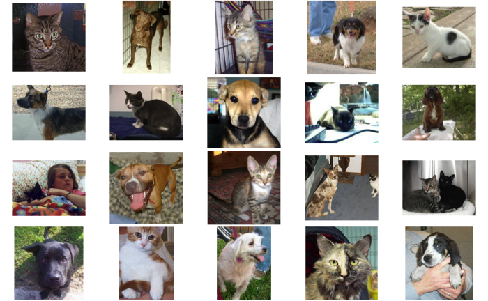

```r
op <- par(mfrow = c(4, 5), pty = "s", mar = c(0.1, 0.1, 0.1, 0.1))
for (i in 1:10) {
  plot(as.raster(jpeg::readJPEG(paste0(train_cats_dir, "/cat.", i, ".jpg"))))
  plot(as.raster(jpeg::readJPEG(paste0(train_dogs_dir, "/dog.", i, ".jpg"))))
}
par(op)
```

# Part 2: Model 1

## Define and compile model

We’re going to set up a simple CNN model that contains steps you saw in the previous module. This CNN includes:

- Four sequential conv and max pooling layers
- Flatten layer
- Densly-connected network
- Single binary output

```r
model <- keras_model_sequential() %>%
  layer_conv_2d(filters = 32, kernel_size = c(3, 3), activation = "relu",
                input_shape = c(150, 150, 3)) %>%
  layer_max_pooling_2d(pool_size = c(2, 2)) %>%

  layer_conv_2d(filters = 64, kernel_size = c(3, 3), activation = "relu") %>%
  layer_max_pooling_2d(pool_size = c(2, 2)) %>%

  layer_conv_2d(filters = 128, kernel_size = c(3, 3), activation = "relu") %>%
  layer_max_pooling_2d(pool_size = c(2, 2)) %>%

  layer_conv_2d(filters = 128, kernel_size = c(3, 3), activation = "relu") %>%
  layer_max_pooling_2d(pool_size = c(2, 2)) %>%

  layer_flatten() %>%

  layer_dense(units = 512, activation = "relu") %>%
  layer_dense(units = 1, activation = "sigmoid")

summary(model)
```

```
Model: "sequential_8"
____________________________________________________________________________________________________________________________
Layer (type)                                           Output Shape                                      Param #
============================================================================================================================
conv2d_3 (Conv2D)                                      (None, 148, 148, 32)                              896
____________________________________________________________________________________________________________________________
max_pooling2d_2 (MaxPooling2D)                         (None, 74, 74, 32)                                0
____________________________________________________________________________________________________________________________
conv2d_4 (Conv2D)                                      (None, 72, 72, 64)                                18496
____________________________________________________________________________________________________________________________
max_pooling2d_3 (MaxPooling2D)                         (None, 36, 36, 64)                                0
____________________________________________________________________________________________________________________________
conv2d_5 (Conv2D)                                      (None, 34, 34, 128)                               73856
____________________________________________________________________________________________________________________________
max_pooling2d_4 (MaxPooling2D)                         (None, 17, 17, 128)                               0
____________________________________________________________________________________________________________________________
conv2d_6 (Conv2D)                                      (None, 15, 15, 128)                               147584
____________________________________________________________________________________________________________________________
max_pooling2d_5 (MaxPooling2D)                         (None, 7, 7, 128)                                 0
____________________________________________________________________________________________________________________________
flatten_1 (Flatten)                                    (None, 6272)                                      0
____________________________________________________________________________________________________________________________
dense_23 (Dense)                                       (None, 512)                                       3211776
____________________________________________________________________________________________________________________________
dense_24 (Dense)                                       (None, 1)                                         513
============================================================================================================================
Total params: 3,453,121
Trainable params: 3,453,121
Non-trainable params: 0
____________________________________________________________________________________________________________________________
```

Compile the model:

```r
model %>% compile(
  loss = "binary_crossentropy",
  optimizer = optimizer_rmsprop(lr = 1e-4),
  metrics = "accuracy"
)
```

## Read images from directories

`image_data_generator` will:

1. Read the image files
2. Decode the image to RGB grids of pixels
3. Convert these into floating point tensors
4. Rescale pixel values to [0, 1] interval

`image_data_generator` provides other capabilities that we’ll look at shortly.

`flow_images_from_directory` will:

1. Apply `image_data_generator`
2. To a batch of 20 images at a time
3. From our training directory (randomly shuffling btwn subdirectories)
4. Resize these images to be consistent size of 150x150 pixels
5. Apply binary labels

```r
train_datagen <- image_data_generator(rescale = 1/255)
valid_datagen <- image_data_generator(rescale = 1/255)

train_generator <- flow_images_from_directory(
  train_dir,
  train_datagen,
  target_size = c(150, 150),
  batch_size = 20,
  class_mode = "binary"
)

validation_generator <- flow_images_from_directory(
  valid_dir,
  valid_datagen,
  target_size = c(150, 150),
  batch_size = 20,
  class_mode = "binary"
)
```

If we get the first batch from the generator, you will see that it yields 20 images of 150x150 pixels with three channels (20, 150, 150, 3) along with their binary labels (0, 1).

```r
batch <- generator_next(train_generator)
str(batch)
```

```
List of 2
 $ : num [1:20, 1:150, 1:150, 1:3] 0.816 0.529 0.82 0.741 0.51 ...
 $ : num [1:20(1d)] 0 0 1 1 0 1 0 0 1 1 ...
```

## Train the model

**Without a GPU this will take approximately 20 minutes to train**

View history

```r
plot(history)
```

[output not shown]

# Save the model

```r
model %>% save_model_hdf5("cats_and_dogs_small_1.h5")
```

# Part 3: Model 2 with image augmentation

## Image Augmentation

```r
datagen <- image_data_generator(
  rescale = 1/255,
  rotation_range = 40,
  width_shift_range = 0.2,
  height_shift_range = 0.2,
  shear_range = 0.2,
  zoom_range = 0.2,
  horizontal_flip = TRUE,
  fill_mode = "nearest"
)
```

The following helps to visualize the idea of image augmentation by:

- Reading in the first image and resizing it to 150x150,
- Converting it to an array with shape (150, 150, 3),
- Reshaping it to (1, 150, 150, 3),
- Generating batches of randomly transformed images.

```r
# get the first cat image
fnames <- list.files(train_cats_dir, full.names = TRUE)
img_path <- fnames[[1]]

# resize & reshape
img <- image_load(img_path, target_size = c(150, 150))
img_array <- image_to_array(img)
img_array <- array_reshape(img_array, c(1, 150, 150, 3))

# generate a a single augmented image
augmentation_generator <- flow_images_from_data(
  img_array,
  generator = datagen,
  batch_size = 1
)

# plot 10 augmented images of the first cat image
op <- par(mfrow = c(2, 5), pty = "s", mar = c(0, 0.1, 0, 0.1))
for (i in 1:10) {
  batch <- generator_next(augmentation_generator)
  plot(as.raster(batch[1,,,]))
}
par(op)
```

[output not shown]

## Model 2

Let’s create a new model that includes image augmentation and we’ll apply the dropout regularization method. The following creates a CNN architecture with:

- Four sequential conv and max pooling layers
- Flatten layer
- Dropout layer (new)
- Densly-connected network
- Single binary output

```r
model <- keras_model_sequential() %>%
  layer_conv_2d(filters = 32, kernel_size = c(3, 3), activation = "relu", input_shape = c(150, 150, 3)) %>%
  layer_max_pooling_2d(pool_size = c(2, 2)) %>%
  layer_conv_2d(filters = 64, kernel_size = c(3, 3), activation = "relu") %>%
  layer_max_pooling_2d(pool_size = c(2, 2)) %>%
  layer_conv_2d(filters = 128, kernel_size = c(3, 3), activation = "relu") %>%
  layer_max_pooling_2d(pool_size = c(2, 2)) %>%
  layer_conv_2d(filters = 128, kernel_size = c(3, 3), activation = "relu") %>%
  layer_max_pooling_2d(pool_size = c(2, 2)) %>%
  layer_flatten() %>%
  layer_dropout(rate = 0.5) %>%
  layer_dense(units = 512, activation = "relu") %>%
  layer_dense(units = 1, activation = "sigmoid")

model %>% compile(
  loss = "binary_crossentropy",
  optimizer = optimizer_rmsprop(lr = 1e-4),
  metrics = "accuracy"
)
```

```r
model %>% save_model_hdf5("cats_and_dogs_small_2.h5")
```